# Assignment 3

The US Department of Agriculture publishes price estimates for fruits and vegetables [online](https://www.ers.usda.gov/data-products/fruit-and-vegetable-prices/fruit-and-vegetable-prices/). The most recent estimates are based on a 2013 survey of US retail stores.

The estimates are provided as a collection of MS Excel files, with one file per fruit or vegetable. The `assignment3_data.zip` file contains the fruit and vegetable files in the directories `fruit` and `vegetables`, respectively.

**Exercise 1.1.** Use pandas to extract the "Fresh" row(s) from the **fruit** Excel files. Combine the data into a single data frame. Your data frame should look something like this:

| type | food | form | price_per_lb | yield | lb_per_cup | price_per_cup |
| --- | --- | --- | --- | --- | --- | --- |
| fruit | watermelon | Fresh1 | 0.333412 | 0.52 | 0.330693 | 0.212033 |
| fruit | cantaloupe | Fresh1 | 0.535874 | 0.51 | 0.374786 | 0.3938 |
| vegetables | onions | Fresh1 | 1.03811 | 0.9 | 0.35274 | 0.406868 |
| ... |  |  |  |  |  |  |

It's okay if the rows and columns of your data frame are in a different order. These modules are especially relevant:

- [`str` methods](https://docs.python.org/2/library/stdtypes.html#string-methods)
- [`os`](https://docs.python.org/2/library/os.html)
- [`os.path`](https://docs.python.org/2/library/os.path.html)
- [pandas](http://pandas.pydata.org/pandas-docs/stable/): `read_excel()`, `concat()`, `.fillna()`, `.str`, plotting methods

Ask questions and search the documentation/web to find the functions you need.

```python
from os import listdir
import pandas as pd
import numpy as np
'''Gets all file names'''
fruits = listdir('C:/Python27/mod1/fruit')
allfiles = []
for i in range(0, len(fruits)):
    allfiles.append('C:/Python27/mod1/fruit/' + fruits[i])
'''Gets all the names of the fruits and strips the .xlsx which is the last 5 characters
For whatever reason, the dot has trouble being stripped together'''
allfruits = []
for i in range(0, len(fruits)):
    allfruits.append(fruits[i])
    allfruits[i] = allfruits[i].rstrip(allfruits[i][-4:])
    allfruits[i] = allfruits[i].rstrip(allfruits[i][-1])
'''Creates empty lists
I extract the fresh column in each file which happens to be all in the same place and stores each value I need into a different list'''
price_per_lb =[]
yields = []
lb_per_cup = []
price_per_cup = []
for i in range(0, len(fruits)):
    tempfile = pd.read_excel(allfiles[i])
    fresh = tempfile.loc[2, :]
    price_per_lb.append(float(fresh[1]))
    yields.append(float(fresh[3]))
    lb_per_cup.append(float(fresh[4]))
    price_per_cup.append(float(fresh[6]))
'''Copies the fruit text the number of fruits there are for data frame creation'''
category = []
for i in range(0, len(fruits)):
    category.append("fruit")
'''Creates fruit dataframe'''
dffruit = pd.DataFrame({'Type': category, 'Name': allfruits, 'price/lb': price_per_lb, 'yield': yields, 'lb/cup': lb_per_cup, 'price/cup': price_per_cup})
dffruit
```

|  | Name | Type | lb/cup | price/cup | price/lb | yield |
| --- | --- | --- | --- | --- | --- | --- |
| 0 | apples | fruit | 0.242508 | 0.422373 | 1.567515 | 0.90 |
| 1 | apricots | fruit | 0.363763 | 1.189102 | 3.040072 | 0.93 |
| 2 | bananas | fruit | 0.330693 | 0.292965 | 0.566983 | 0.64 |
| 3 | berries_mixed | fruit | 0.330693 | 1.127735 | 3.410215 | 1.00 |
| 4 | blackberries | fruit | 0.319670 | 1.922919 | 5.774708 | 0.96 |
| 5 | blueberries | fruit | 0.319670 | 1.593177 | 4.734622 | 0.95 |
| 6 | cantaloupe | fruit | 0.374786 | 0.393800 | 0.535874 | 0.51 |
| 7 | cherries | fruit | 0.341717 | 1.334548 | 3.592990 | 0.92 |
| 8 | cranberries | fruit | 0.123163 | 0.589551 | 4.786741 | 1.00 |
| 9 | dates | fruit | 0.165347 | 0.792234 | 4.791351 | 1.00 |
| 10 | figs | fruit | 0.165347 | 0.990068 | 5.748318 | 0.96 |
| 11 | fruit_cocktail | fruit | NaN | NaN | NaN | NaN |
| 12 | grapefruit | fruit | 0.462971 | 0.848278 | 0.897802 | 0.49 |
| 13 | grapes | fruit | 0.330693 | 0.721266 | 2.093827 | 0.96 |
| 14 | honeydew | fruit | 0.374786 | 0.649077 | 0.796656 | 0.46 |
| 15 | kiwi | fruit | 0.385809 | 1.037970 | 2.044683 | 0.76 |
| 16 | mangoes | fruit | 0.363763 | 0.705783 | 1.377563 | 0.71 |
| 17 | nectarines | fruit | 0.319670 | 0.618667 | 1.761148 | 0.91 |
| 18 | oranges | fruit | 0.407855 | 0.578357 | 1.035173 | 0.73 |
| 19 | papaya | fruit | 0.308647 | 0.646174 | 1.298012 | 0.62 |
| 20 | peaches | fruit | 0.341717 | 0.566390 | 1.591187 | 0.96 |
| 21 | pears | fruit | 0.363763 | 0.590740 | 1.461575 | 0.90 |
| 22 | pineapple | fruit | 0.363763 | 0.447686 | 0.627662 | 0.51 |
| 23 | plums | fruit | 0.363763 | 0.707176 | 1.827416 | 0.94 |
| 24 | pomegranate | fruit | 0.341717 | 1.326342 | 2.173590 | 0.56 |
| 25 | raspberries | fruit | 0.319670 | 2.322874 | 6.975811 | 0.96 |
| 26 | strawberries | fruit | 0.319670 | 0.802171 | 2.358808 | 0.94 |
| 27 | tangerines | fruit | 0.407855 | 0.759471 | 1.377962 | 0.74 |
| 28 | watermelon | fruit | 0.330693 | 0.212033 | 0.333412 | 0.52 |

**Exercise 1.2.** Reuse your code from exercise 1.1 to extract the "Fresh" row(s) from the **vegetable** Excel files.

Does your code produce the correct prices for tomatoes? If not, why not? Do any other files have the same problem as the tomatoes file?

You don't need to extract the prices for these problem files. However, make sure the prices are extracted for files like asparagus that don't have this problem.

```python
from os import listdir
import pandas as pd
import numpy as np
'''Gets all file names'''
vegetables = listdir('C:/Python27/mod1/vegetables')
allfiles2 = []
for i in range(0, len(vegetables)):
    allfiles2.append('C:/Python27/mod1/vegetables/' + vegetables[i])
'''Gets all the names of the fruits and strips the .xlsx which is the last 5 characters'''
allveggies = []
for i in range(0, len(vegetables)):
    allveggies.append(vegetables[i])
    allveggies[i] = allveggies[i].rstrip(allveggies[i][-4:])
    allveggies[i] = allveggies[i].rstrip(allveggies[i][-1])
'''Creates empty lists
I extract the fresh column in each file which happens to be all in the same place and stores each value I need into a different list'''
price_per_lb2 =[]
yields2 = []
lb_per_cup2 = []
price_per_cup2 = []
for i in range(0, len(vegetables)):
    tempfile2 = pd.read_excel(allfiles2[i])
    fresh2 = tempfile2.loc[2, :]
    '''I noticed there was an error with one of the prices as a string so I converted it to NaN string instead'''
    try:
        price_per_lb2.append(float(fresh2[1]))
    except ValueError:
        price_per_lb2.append(np.nan)
    '''Same with yields and other values'''
    try:
        yields2.append(float(fresh2[3]))
    except ValueError:
        yields2.append(np.nan)
    try:
        lb_per_cup2.append(float(fresh2[4]))
    except ValueError:
        lb_per_cup2.append(np.nan)
    price_per_cup2.append(float(fresh2[6]))
'''Copies the fruit text the number of fruits there are for data frame creation'''
category2 = []
for i in range(0, len(vegetables)):
    category2.append("vegetable")
'''Creates fruit dataframe'''
dfveg = pd.DataFrame({'Type': category2, 'Name': allveggies, 'price/lb': price_per_lb2, 'yield': yields2, 'lb/cup': lb_per_cup2, 'price/cup': price_per_cup2})
dfveg
```

|  | Name | Type | lb/cup | price/cup | price/lb | yield |
| --- | --- | --- | --- | --- | --- | --- |
| 0 | acorn_squash | vegetable | 0.451948 | 1.155360 | 1.172248 | 0.458554 |
| 1 | artichoke | vegetable | 0.385809 | 2.274967 | 2.213050 | 0.375309 |
| 2 | asparagus | vegetable | 0.396832 | 2.582272 | 3.213494 | 0.493835 |
| 3 | avocados | vegetable | 0.319670 | 0.964886 | 2.235874 | 0.740753 |
| 4 | beets | vegetable | 0.374786 | 0.586555 | 1.017275 | 0.650000 |
| 5 | blackeye_peas | vegetable | 0.374786 | 0.524954 | 0.910441 | 0.650000 |
| 6 | black_beans | vegetable | 0.385809 | 0.582025 | 0.980580 | 0.650000 |
| 7 | broccoli | vegetable | NaN | NaN | NaN | NaN |
| 8 | brussels_sprouts | vegetable | 0.341717 | 0.890898 | 2.763553 | 1.060000 |
| 9 | butternut_squash | vegetable | 0.451948 | 0.787893 | 1.244737 | 0.714000 |
| 10 | cabbage | vegetable | 0.330693 | 0.245944 | 0.579208 | 0.778797 |
| 11 | carrots | vegetable | NaN | NaN | NaN | NaN |
| 12 | cauliflower | vegetable | NaN | NaN | NaN | NaN |
| 13 | celery | vegetable | NaN | NaN | NaN | NaN |
| 14 | collard_greens | vegetable | 0.286601 | 0.650001 | 2.630838 | 1.160000 |
| 15 | corn_sweet | vegetable | 0.363763 | 1.812497 | 2.690623 | 0.540000 |
| 16 | cucumbers | vegetable | 0.264555 | 0.353448 | 1.295931 | 0.970000 |
| 17 | great_northern_beans | vegetable | 0.385809 | 0.548392 | 0.923916 | 0.650000 |
| 18 | green_beans | vegetable | 0.275578 | 0.696606 | 2.139972 | 0.846575 |
| 19 | green_peas | vegetable | 0.352740 | 0.549769 | 1.013069 | 0.650000 |
| 20 | green_peppers | vegetable | 0.264555 | 0.455022 | 1.410363 | 0.820000 |
| 21 | kale | vegetable | 0.286601 | 0.766262 | 2.807302 | 1.050000 |
| 22 | kidney_beans | vegetable | 0.385809 | 0.535194 | 0.901680 | 0.650000 |
| 23 | lentils | vegetable | 0.385809 | 0.196738 | 1.385036 | 2.716095 |
| 24 | lettuce_iceberg | vegetable | 0.242508 | 0.309655 | 1.213039 | 0.950000 |
| 25 | lettuce_romaine | vegetable | NaN | NaN | NaN | NaN |
| 26 | lima_beans | vegetable | 0.374786 | 0.797757 | 1.383569 | 0.650000 |
| 27 | mixed_vegetables | vegetable | NaN | NaN | NaN | NaN |
| 28 | mushrooms | vegetable | NaN | NaN | NaN | NaN |
| 29 | mustard_greens | vegetable | 0.308647 | 0.944032 | 2.569235 | 0.840000 |
| 30 | navy_beans | vegetable | 0.385809 | 0.575997 | 0.970423 | 0.650000 |
| 31 | okra | vegetable | 0.352740 | 1.473146 | 3.213552 | 0.769474 |
| 32 | olives | vegetable | 0.297624 | 1.246102 | 4.186832 | 1.000000 |
| 33 | onions | vegetable | 0.352740 | 0.406868 | 1.038107 | 0.900000 |
| 34 | pinto_beans | vegetable | 0.385809 | 0.514129 | 0.866190 | 0.650000 |
| 35 | potatoes | vegetable | 0.264555 | 0.184017 | 0.564320 | 0.811301 |
| 36 | pumpkin | vegetable | 0.540133 | 0.730411 | 1.352280 | 1.000000 |
| 37 | radish | vegetable | 0.275578 | 0.401618 | 1.311629 | 0.900000 |
| 38 | red_peppers | vegetable | 0.264555 | 0.734926 | 2.277940 | 0.820000 |
| 39 | spinach | vegetable | NaN | NaN | NaN | NaN |
| 40 | summer_squash | vegetable | 0.396832 | 0.845480 | 1.639477 | 0.769500 |
| 41 | sweet_potatoes | vegetable | 0.440925 | 0.499400 | 0.918897 | 0.811301 |
| 42 | tomatoes | vegetable | NaN | NaN | NaN | NaN |
| 43 | turnip_greens | vegetable | 0.319670 | 1.053526 | 2.471749 | 0.750000 |

**Exercise 1.3.** Remove rows without a price from the vegetable data frame and then combine the fruit and vegetable data frames. Make sure all columns of numbers are numeric (not strings).

```python
import numpy as np
'''Drops cocktail'''
newdffruit = dffruit.loc[np.isnan(dffruit['price/lb']) == False]
newdffruit
'''Drop all the NaN vegetable observations'''
newdfveg = dfveg.loc[np.isnan(dfveg['price/lb']) == False]
newdfveg
'''Merge dataframes'''
foods = [newdffruit, newdfveg]
dffoods = pd.concat(foods)
dffoods
```

|  | Name | Type | lb/cup | price/cup | price/lb | yield |
| --- | --- | --- | --- | --- | --- | --- |
| 0 | apples | fruit | 0.242508 | 0.422373 | 1.567515 | 0.900000 |
| 1 | apricots | fruit | 0.363763 | 1.189102 | 3.040072 | 0.930000 |
| 2 | bananas | fruit | 0.330693 | 0.292965 | 0.566983 | 0.640000 |
| 3 | berries_mixed | fruit | 0.330693 | 1.127735 | 3.410215 | 1.000000 |
| 4 | blackberries | fruit | 0.319670 | 1.922919 | 5.774708 | 0.960000 |
| 5 | blueberries | fruit | 0.319670 | 1.593177 | 4.734622 | 0.950000 |
| 6 | cantaloupe | fruit | 0.374786 | 0.393800 | 0.535874 | 0.510000 |
| 7 | cherries | fruit | 0.341717 | 1.334548 | 3.592990 | 0.920000 |
| 8 | cranberries | fruit | 0.123163 | 0.589551 | 4.786741 | 1.000000 |
| 9 | dates | fruit | 0.165347 | 0.792234 | 4.791351 | 1.000000 |
| 10 | figs | fruit | 0.165347 | 0.990068 | 5.748318 | 0.960000 |
| 12 | grapefruit | fruit | 0.462971 | 0.848278 | 0.897802 | 0.490000 |
| 13 | grapes | fruit | 0.330693 | 0.721266 | 2.093827 | 0.960000 |
| 14 | honeydew | fruit | 0.374786 | 0.649077 | 0.796656 | 0.460000 |
| 15 | kiwi | fruit | 0.385809 | 1.037970 | 2.044683 | 0.760000 |
| 16 | mangoes | fruit | 0.363763 | 0.705783 | 1.377563 | 0.710000 |
| 17 | nectarines | fruit | 0.319670 | 0.618667 | 1.761148 | 0.910000 |
| 18 | oranges | fruit | 0.407855 | 0.578357 | 1.035173 | 0.730000 |
| 19 | papaya | fruit | 0.308647 | 0.646174 | 1.298012 | 0.620000 |
| 20 | peaches | fruit | 0.341717 | 0.566390 | 1.591187 | 0.960000 |
| 21 | pears | fruit | 0.363763 | 0.590740 | 1.461575 | 0.900000 |
| 22 | pineapple | fruit | 0.363763 | 0.447686 | 0.627662 | 0.510000 |
| 23 | plums | fruit | 0.363763 | 0.707176 | 1.827416 | 0.940000 |
| 24 | pomegranate | fruit | 0.341717 | 1.326342 | 2.173590 | 0.560000 |
| 25 | raspberries | fruit | 0.319670 | 2.322874 | 6.975811 | 0.960000 |
| 26 | strawberries | fruit | 0.319670 | 0.802171 | 2.358808 | 0.940000 |
| 27 | tangerines | fruit | 0.407855 | 0.759471 | 1.377962 | 0.740000 |
| 28 | watermelon | fruit | 0.330693 | 0.212033 | 0.333412 | 0.520000 |
| 0 | acorn_squash | vegetable | 0.451948 | 1.155360 | 1.172248 | 0.458554 |
| 1 | artichoke | vegetable | 0.385809 | 2.274967 | 2.213050 | 0.375309 |
| ... | ... | ... | ... | ... | ... | ... |
| 5 | blackeye_peas | vegetable | 0.374786 | 0.524954 | 0.910441 | 0.650000 |
| 6 | black_beans | vegetable | 0.385809 | 0.582025 | 0.980580 | 0.650000 |
| 8 | brussels_sprouts | vegetable | 0.341717 | 0.890898 | 2.763553 | 1.060000 |
| 9 | butternut_squash | vegetable | 0.451948 | 0.787893 | 1.244737 | 0.714000 |
| 10 | cabbage | vegetable | 0.330693 | 0.245944 | 0.579208 | 0.778797 |
| 14 | collard_greens | vegetable | 0.286601 | 0.650001 | 2.630838 | 1.160000 |
| 15 | corn_sweet | vegetable | 0.363763 | 1.812497 | 2.690623 | 0.540000 |
| 16 | cucumbers | vegetable | 0.264555 | 0.353448 | 1.295931 | 0.970000 |
| 17 | great_northern_beans | vegetable | 0.385809 | 0.548392 | 0.923916 | 0.650000 |
| 18 | green_beans | vegetable | 0.275578 | 0.696606 | 2.139972 | 0.846575 |
| 19 | green_peas | vegetable | 0.352740 | 0.549769 | 1.013069 | 0.650000 |
| 20 | green_peppers | vegetable | 0.264555 | 0.455022 | 1.410363 | 0.820000 |
| 21 | kale | vegetable | 0.286601 | 0.766262 | 2.807302 | 1.050000 |
| 22 | kidney_beans | vegetable | 0.385809 | 0.535194 | 0.901680 | 0.650000 |
| 23 | lentils | vegetable | 0.385809 | 0.196738 | 1.385036 | 2.716095 |
| 24 | lettuce_iceberg | vegetable | 0.242508 | 0.309655 | 1.213039 | 0.950000 |
| 26 | lima_beans | vegetable | 0.374786 | 0.797757 | 1.383569 | 0.650000 |
| 29 | mustard_greens | vegetable | 0.308647 | 0.944032 | 2.569235 | 0.840000 |
| 30 | navy_beans | vegetable | 0.385809 | 0.575997 | 0.970423 | 0.650000 |
| 31 | okra | vegetable | 0.352740 | 1.473146 | 3.213552 | 0.769474 |
| 32 | olives | vegetable | 0.297624 | 1.246102 | 4.186832 | 1.000000 |
| 33 | onions | vegetable | 0.352740 | 0.406868 | 1.038107 | 0.900000 |
| 34 | pinto_beans | vegetable | 0.385809 | 0.514129 | 0.866190 | 0.650000 |
| 35 | potatoes | vegetable | 0.264555 | 0.184017 | 0.564320 | 0.811301 |
| 36 | pumpkin | vegetable | 0.540133 | 0.730411 | 1.352280 | 1.000000 |
| 37 | radish | vegetable | 0.275578 | 0.401618 | 1.311629 | 0.900000 |
| 38 | red_peppers | vegetable | 0.264555 | 0.734926 | 2.277940 | 0.820000 |
| 40 | summer_squash | vegetable | 0.396832 | 0.845480 | 1.639477 | 0.769500 |
| 41 | sweet_potatoes | vegetable | 0.440925 | 0.499400 | 0.918897 | 0.811301 |
| 43 | turnip_greens | vegetable | 0.319670 | 1.053526 | 2.471749 | 0.750000 |

63 rows × 6 columns

**Exercise 1.4.** Discuss the questions below (a paragraph each is sufficient). Use plots to support your ideas.

- What kinds of fruits are the most expensive (per pound)? What kinds are the least expensive?
- How do the price distributions compare for fruit and vegetables?
- Which foods are the best value for the price?
- What's something surprising about this data set?
- Which foods do you expect to provide the best combination of price, yield, and nutrition? A future assignment may combine this data set with another so you can check your hypothesis.

```python
fruit = dffoods.loc[dffoods['Type'] == "fruit"]
maxprice = fruit['price/lb'].max()
maxfruit = dffoods.loc[dffoods['price/lb'] == maxprice]
'''I do not know why this won't return a string if I only grab the name. Had to look this up on Stack Overflow
http://stackoverflow.com/questions/16729574/how-to-get-a-value-from-a-cell-of-a-data-frame'''
maxfruit = maxfruit.iloc[0]['Name']
minprice = fruit['price/lb'].min()
minfruit = dffoods.loc[dffoods['price/lb'] == minprice]
minfruit = minfruit.iloc[0]['Name']
print maxfruit, maxprice, minfruit, minprice
```

```
raspberries 6.97581079886 watermelon 0.333412035323
```

I separated the dataset back into the two parts, one containing all the fruits and one containing all the vegetables. From there I got the minimum and maximum prices and found which fruits and vegetables they belonged to. Then I found that the most expensive fruit per pound are raspberries and the least expensive fruit per pound are watermelons. I did take some of the observations out containing N/A for the prices in the dataset so this could possibly be wrong and that not all the types of fruits and vegetables are in the dataset.

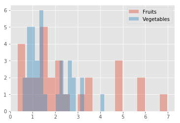

```python
from matplotlib import pyplot as plt
import matplotlib
matplotlib.style.use('ggplot')
vegetable = dffoods.loc[dffoods['Type'] == "vegetable"]
plt.hist(fruit['price/lb'], bins = 20, alpha = 0.4, label = "Fruits")
plt.hist(vegetable['price/lb'], bins = 20, alpha = 0.4, label = "Vegetables")
plt.legend()
plt.show()
```

I plotted a histogram for both fruits and vegetables to get a sense of the price distributions and the number of fruits or vegetables at each price. From this plot, it looks like fruits are more expensive than vegetables in general. Most fruits and vegetables cost around 0 to less than 4 dollars in terms of price per pound and based on the plot, only fruits costs more than 5 dollars per pound. Most of the vegetables seem to cost around 50 cents to 1.5 dollars per pound. There could possibly be more vegetables that are as expensive as the fruits in the outlier parts of the graph as some observations are taken out of the dataset.

```python
ratio = dffoods['price/lb']/dffoods['yield']
dffoods['ratio'] = ratio
dffoods
maxratio = dffoods['ratio'].max()
bestvalue = dffoods.loc[dffoods['ratio'] == maxratio]
bestvalue = bestvalue.iloc[0]['Name']
minratio = dffoods['ratio'].min()
worstvalue = dffoods.loc[dffoods['ratio'] == minratio]
worstvalue = worstvalue.iloc[0]['Name']
print bestvalue, maxratio, worstvalue, minratio
```

```
raspberries 7.26646958214 lentils 0.509936423192
```

```python
maxvegprice = vegetable['price/lb'].max()
maxveg = dffoods.loc[dffoods['price/lb'] == maxvegprice]
maxveg = maxveg.iloc[0]['Name']
minvegprice = vegetable['price/lb'].min()
minveg = dffoods.loc[dffoods['price/lb'] == minvegprice]
minveg = minveg.iloc[0]['Name']
print maxveg, maxvegprice, minveg, minvegprice
```

```
olives 4.18683171458 potatoes 0.564319813929
```

```python
expveg = dfveg.loc[dfveg['price/lb'] > 4]
expfruit = dffruit.loc[dffruit['price/lb'] > 4]
cheapveg = dfveg.loc[dfveg['price/lb'] < 1]
cheapfruit = dffruit.loc[dffruit['price/lb'] < 1]
print expveg, expfruit
print cheapveg, cheapfruit
```

```
      Name       Type    lb/cup  price/cup  price/lb  yield
32  olives  vegetable  0.297624   1.246102  4.186832    1.0             Name   Type    lb/cup  price/cup  price/lb  yield
4   blackberries  fruit  0.319670   1.922919  5.774708   0.96
5    blueberries  fruit  0.319670   1.593177  4.734622   0.95
8    cranberries  fruit  0.123163   0.589551  4.786741   1.00
9          dates  fruit  0.165347   0.792234  4.791351   1.00
10          figs  fruit  0.165347   0.990068  5.748318   0.96
25   raspberries  fruit  0.319670   2.322874  6.975811   0.96
                    Name       Type    lb/cup  price/cup  price/lb     yield
5          blackeye_peas  vegetable  0.374786   0.524954  0.910441  0.650000
6            black_beans  vegetable  0.385809   0.582025  0.980580  0.650000
10               cabbage  vegetable  0.330693   0.245944  0.579208  0.778797
17  great_northern_beans  vegetable  0.385809   0.548392  0.923916  0.650000
22          kidney_beans  vegetable  0.385809   0.535194  0.901680  0.650000
30            navy_beans  vegetable  0.385809   0.575997  0.970423  0.650000
34           pinto_beans  vegetable  0.385809   0.514129  0.866190  0.650000
35              potatoes  vegetable  0.264555   0.184017  0.564320  0.811301
41        sweet_potatoes  vegetable  0.440925   0.499400  0.918897  0.811301           Name   Type    lb/cup  price/cup  price/lb  yield
2      bananas  fruit  0.330693   0.292965  0.566983   0.64
6   cantaloupe  fruit  0.374786   0.393800  0.535874   0.51
12  grapefruit  fruit  0.462971   0.848278  0.897802   0.49
14    honeydew  fruit  0.374786   0.649077  0.796656   0.46
22   pineapple  fruit  0.363763   0.447686  0.627662   0.51
28  watermelon  fruit  0.330693   0.212033  0.333412   0.52
```

Something that surprised me in the dataset is that there are more fruits that cost a lot than vegetables are. I expected berries to cost more than 4 dollars per pound but did not expect olives, dates, and figs to cost so much too, especially figs which is $5.74 per pound. I found that pineapples costs less than 1 dollar per pound as well which made me surprised because they usually cost a lot more in the market from what I've seen. I'm also surprised that corn isn't in the list of the cheaper vegetables because I've learned from previous classes that producers generally produce a lot of corn, potatoes, and beans so I'd expect them to have cheaper prices. From what I just saw for the more expensive and cheaper foods, most beans and potato varieties are in the list of cheaper vegetables I've got but corn isn't one of them.

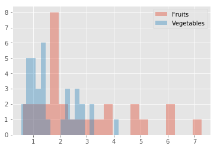

```python
from matplotlib import pyplot as plt
import matplotlib
matplotlib.style.use('ggplot')
fruit = dffoods.loc[dffoods['Type'] == "fruit"]
vegetable = dffoods.loc[dffoods['Type'] == "vegetable"]
plt.hist(fruit['ratio'], bins = 20, alpha = 0.4, label = "Fruits")
plt.hist(vegetable['price/lb'], bins = 20, alpha = 0.4, label = "Vegetables")
plt.legend()
plt.show()
```

```python
bval = dffoods.loc[dffoods['ratio'] > 4]
wval = dffoods.loc[dffoods['ratio'] < 1]
print bval
print wval
```

```
            Name       Type    lb/cup  price/cup  price/lb     yield     ratio
4   blackberries      fruit  0.319670   1.922919  5.774708  0.960000  6.015321
5    blueberries      fruit  0.319670   1.593177  4.734622  0.950000  4.983812
8    cranberries      fruit  0.123163   0.589551  4.786741  1.000000  4.786741
9          dates      fruit  0.165347   0.792234  4.791351  1.000000  4.791351
10          figs      fruit  0.165347   0.990068  5.748318  0.960000  5.987831
25   raspberries      fruit  0.319670   2.322874  6.975811  0.960000  7.266470
1      artichoke  vegetable  0.385809   2.274967  2.213050  0.375309  5.896615
2      asparagus  vegetable  0.396832   2.582272  3.213494  0.493835  6.507216
15    corn_sweet  vegetable  0.363763   1.812497  2.690623  0.540000  4.982635
31          okra  vegetable  0.352740   1.473146  3.213552  0.769474  4.176299
32        olives  vegetable  0.297624   1.246102  4.186832  1.000000  4.186832
          Name       Type    lb/cup  price/cup  price/lb     yield     ratio
2      bananas      fruit  0.330693   0.292965  0.566983  0.640000  0.885912
28  watermelon      fruit  0.330693   0.212033  0.333412  0.520000  0.641177
10     cabbage  vegetable  0.330693   0.245944  0.579208  0.778797  0.743722
23     lentils  vegetable  0.385809   0.196738  1.385036  2.716095  0.509936
35    potatoes  vegetable  0.264555   0.184017  0.564320  0.811301  0.695574
```